# mbhard — do SIFT3D landmarks help affine initialisation and Sobolev SyN?

Generated 2026-09-14 17:13 by `scripts/benchmark_mbhard_landmark_guidance.py`. Pair: NKI-TRT-20-2 (fixed) → MMRR-21-2 (moving), DKT31 manual labels. Preprocessing: NLM denoise (antstorch, MPS), no N4, 2-98% norm. Landmarks: `match_sift3d_with_rotation_search` → 182 RANSAC-affine inlier pairs (75% share a whole-brain label; global rotation 0.0°), 16 s.

## Part 1 — affine initialisation

A: `robust_affine(mode='auto')`. B: least-squares affine on the inlier landmark pairs. C: B refined by intensity (`robust_affine(initial_transform=B, multi_start=False)`). Similarity is measured between the fixed T1 and the affinely resampled moving T1 (image_compare; ncc_foreground = Pearson on fixed foreground). Dice = bidirectional symmetric DKT31.

| affine | Dice sym | Dice fixed | Dice moving | lncc | ncc | mattes MI | ncc (fg) | time s |
| --- | --- | --- | --- | --- | --- | --- | --- | --- |
| A standard robust_affine | 0.3244 | 0.3243 | 0.3245 | -0.0139 | 0.1296 | -0.2471 | 0.5351 | 59 |
| B landmark least-squares | 0.3259 | 0.3259 | 0.3259 | -0.0145 | 0.1400 | -0.2361 | 0.5510 | 16 |
| C landmark + intensity refine | 0.3237 | 0.3234 | 0.3241 | -0.0145 | 0.1289 | -0.2461 | 0.5264 | 86 |

A vs B: rotation differs by 2.03°, centre-of-mass mapping by 9.61 mm.

## Part 2 — Sobolev SyN with landmark-cluster guidance

All arms start from affine A unless stated; levels [4,2,1], iters [100,100,20], sobolev alpha 1.5, grad_step 0.25. Guidance: k-means clusters of inlier landmarks, 3 mm Gaussian blobs, softmax-like normalisation, soft Dice per cluster channel; channels = [T1 (cc2)] + K cluster maps (soft Dice), weights [1−w] + [w/K]·K.

| arm | Dice sym | Dice fixed | Dice moving | Δ vs baseline | folding % | min J | time s |
| --- | --- | --- | --- | --- | --- | --- | --- |
| baseline cc2 | 0.6025 | 0.6035 | 0.6015 | +0.0000 | 0.00846 | 0.000 | 117 |
| guided K=8 w=0.2 | 0.6121 | 0.6123 | 0.6118 | +0.0096 | 0.02033 | 0.000 | 134 |
| guided K=8 w=0.5 | 0.6057 | 0.6053 | 0.6061 | +0.0032 | 0.00334 | 0.000 | 132 |
| guided K=16 w=0.2 | 0.6107 | 0.6107 | 0.6107 | +0.0082 | 0.01436 | 0.000 | 158 |
| oracle (136 label-agreeing) K=8 w=0.2 | 0.6083 | 0.6094 | 0.6073 | +0.0059 | 0.01017 | 0.000 | 133 |
| landmark affine C + guided K=8 w=0.2 | 0.6069 | 0.6069 | 0.6069 | +0.0045 | 0.00023 | 0.000 | 126 |

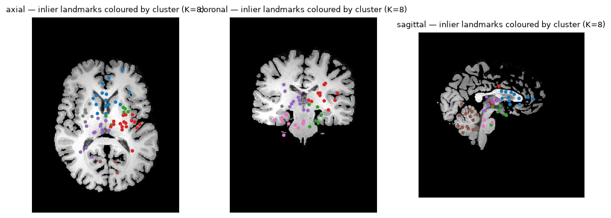

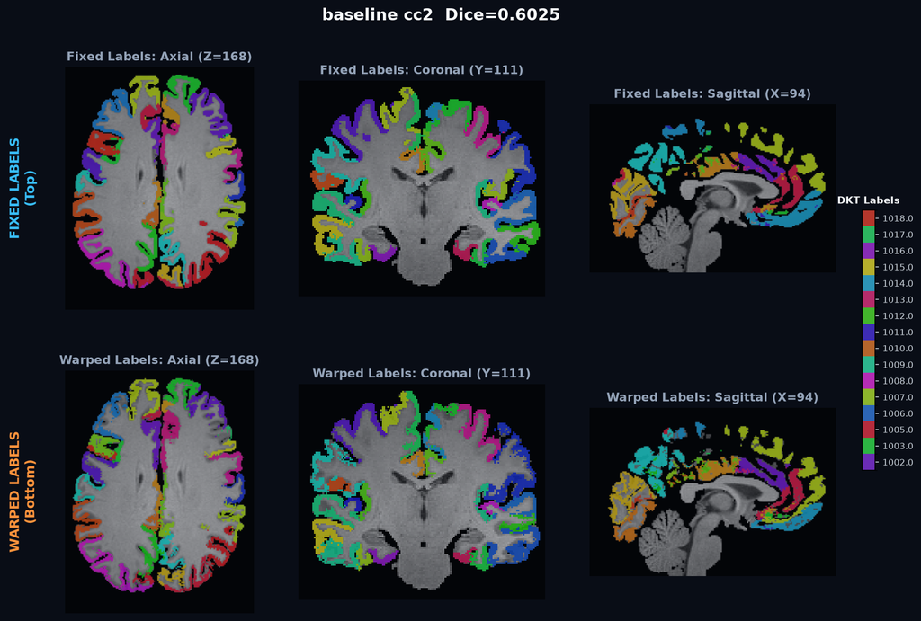

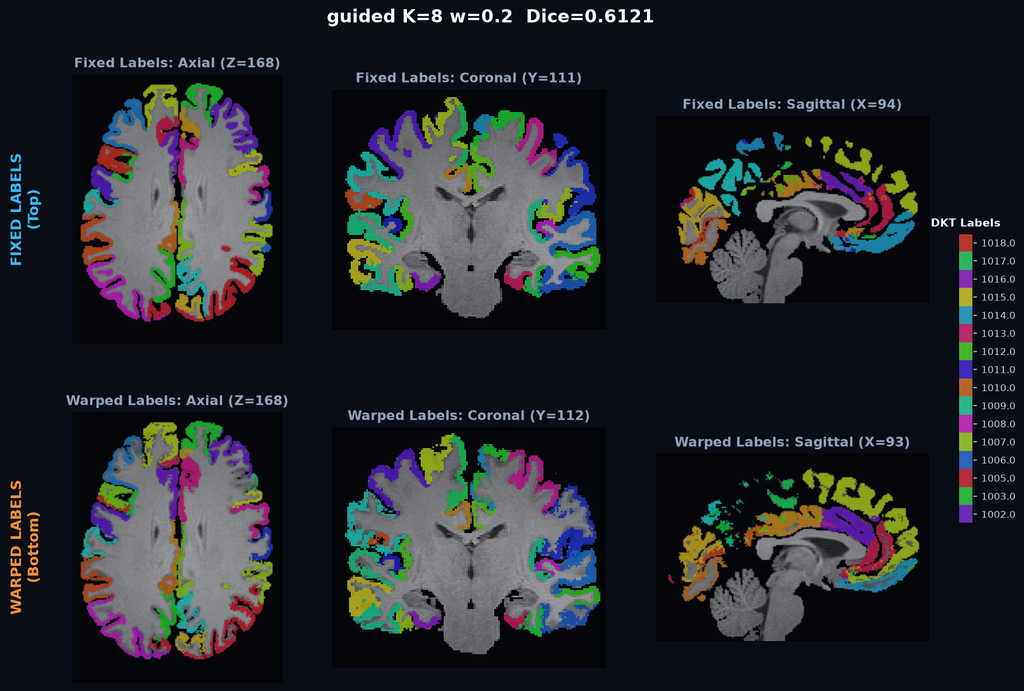